# Lecture12_assignment

For these exercises, we will use a behavioral dataset (s03_behav_hfa.csv) similar to the one we used in Lecture 3, but with some extra info. Here is what the data look like:

A refresher about the game: In the gambling game, subjects are given a choice between a safebet and a risky gamble. Subjects start each trial by looking at a number; if they believe that a second number, initially hidden, will be higher, they should take the bet (both numbers are 0-10). In this dataset there are 188 trials.

The columns in the data file contain behavioral data: * gamble_ind: binary, whether the subject chose to gamble (1) or not (0) in each trial * risk: how risky the choice was on each round * winprob: the probability of the gamble resulting in a win in each trial (takes values [0,1] in 0.1 increments) * regret: how optimal the choice was compared to the alternative (-10 means subject would have made an extra $10 by taking the other option) * rt: reaction time (in s): how long it took the subject to make a decision in each round

In addition, the HFA column contains neural data: the power of high frequency activity (HFA) at a single prefrontal electrode at the time of outcome reveal (when they see the consequence of their choice).

The main experimental question is: is HFA associated with any of the behavioral regressors, and, if so, which is the model that best describes HFA activation?

# Linear regression and associated functions

Start by examining the relationship between HFA and winprob:

```r
data<- read.csv("s03_behav_hfa.csv")
data
```

| ï..gamble_ind | risk | winprob | regret | rt | hfa |
| --- | --- | --- | --- | --- | --- |
| TRUE | 0.24 | 0.6 | 0 | 1.0200000 | -5.20839787 |
| TRUE | 0.21 | 0.3 | 0 | 0.7320001 | 8.40700054 |
| TRUE | 0.09 | 0.9 | 0 | 0.9970000 | -2.32522917 |
| FALSE | 0.24 | 0.4 | 0 | 0.8850000 | 12.33300209 |
| FALSE | 0.21 | 0.3 | 0 | 0.9870000 | 1.88286364 |
| FALSE | 0.09 | 0.1 | 0 | 1.1729999 | 2.13934255 |
| TRUE | 0.21 | 0.7 | 0 | 1.0130000 | 3.55599356 |
| FALSE | 0.24 | 0.4 | -10 | 1.0369999 | 3.06948447 |
| FALSE | 0.21 | 0.3 | 0 | 0.9420002 | -0.94700086 |
| TRUE | 0.24 | 0.6 | 0 | 1.6680000 | 3.10596776 |

[output cut: 178 more lines]

- Plot them as a scatterplot

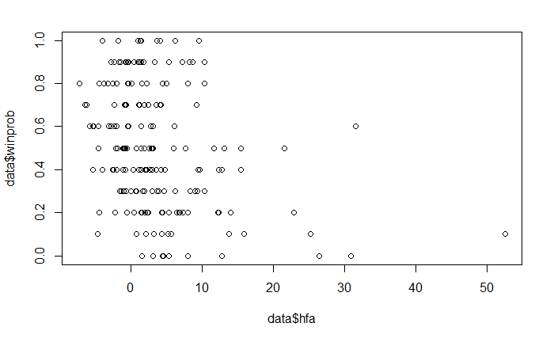

```r
plot(data$hfa, data$winprob)
```

- Run a linear regression

```r
linreg <-lm(data$winprob~data$hfa)
```

- Assign the output to a variable in your workspace for further manipulation
- Use summary() to examine the fit quality and significance

```r
summary(linreg)
```

```
Call:
lm(formula = data$winprob ~ data$hfa)

Residuals:
     Min       1Q   Median       3Q      Max
-0.52855 -0.20135 -0.01824  0.20280  0.56843

Coefficients:
             Estimate Std. Error t value Pr(>|t|)
(Intercept)  0.548666   0.021471  25.554  < 2e-16 ***
data$hfa    -0.012242   0.002662  -4.598 7.87e-06 ***
---
Signif. codes:  0 ‘***’ 0.001 ‘**’ 0.01 ‘*’ 0.05 ‘.’ 0.1 ‘ ’ 1

Residual standard error: 0.2668 on 186 degrees of freedom
Multiple R-squared:  0.1021,    Adjusted R-squared:  0.09723
F-statistic: 21.14 on 1 and 186 DF,  p-value: 7.871e-06
```

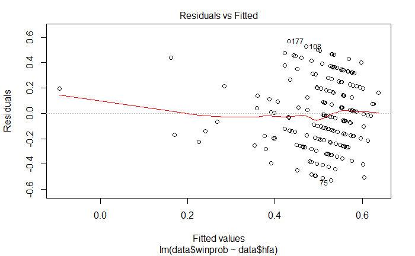

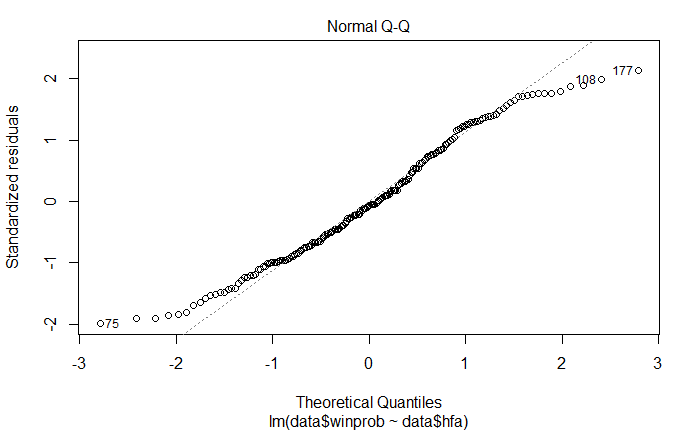

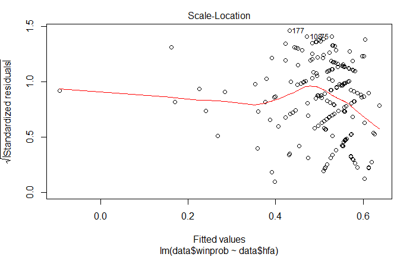

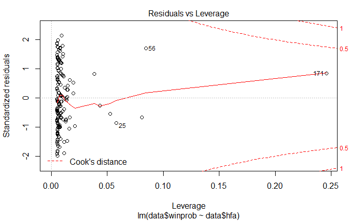

```r
plot(linreg)
```

- Plot the resulting fit on your scatterplot (you can use abline())

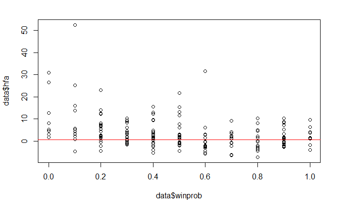

```r
plot(data$winprob, data$hfa)
abline(linreg, col="red") # regression line (y~x) #this still doesnt work for some reason..
```

Next, evaluate whether any of the other regressors show a significant relationship with HFA by running linear regressions for each. * gamble_ind: binary, whether the subject chose to gamble (1) or not (0) in each trial * risk: how risky the choice was on each round * winprob: the probability of the gamble resulting in a win in each trial (takes values [0,1] in 0.1 increments) * regret: how optimal the choice was compared to the alternative (-10 means subject would have made an extra $10 by taking the other option) * rt: reaction time (in s): how long it took the subject to make a decision in each round

```r
#copy the rest:

lmrisk <-lm(data$risk~data$hfa)
summary(lmrisk)
```

```
Call:
lm(formula = data$risk ~ data$hfa)

Residuals:
     Min       1Q   Median       3Q      Max
-0.18676 -0.05677  0.03001  0.06120  0.12656

Coefficients:
              Estimate Std. Error t value Pr(>|t|)
(Intercept)  0.1785693  0.0062779  28.444  < 2e-16 ***
data$hfa    -0.0020602  0.0007785  -2.646  0.00883 **
---
Signif. codes:  0 ‘***’ 0.001 ‘**’ 0.01 ‘*’ 0.05 ‘.’ 0.1 ‘ ’ 1

Residual standard error: 0.078 on 186 degrees of freedom
Multiple R-squared:  0.03629,   Adjusted R-squared:  0.03111
F-statistic: 7.004 on 1 and 186 DF,  p-value: 0.008831
```